# Analysis LR field of large dataset using spWAVE

Kai Li

2025-04-07 (updated 2026-09-24)

In this vignette, we will focus on large dataset processing and field estimation. Such large datasets are often single cell resolutions and have large number of cells but limited transcript coverage, like 10x Xenium and MERFISH/MERSCOPE. To reduce the compute complexity and resource consumption, we will introduce an alternative “holed manner” method. In short, for those out of range(e.g. >500 micrometer) cells, we aggregate them into multiple meta-cells and keep all in-range single cells to calculate the interaction field.

Besides, we will show some methods to create spWAVE object from different sources and select ROI to estimate the field.

Let’s start by loading the required libraries.

```r
library(magrittr)
library(dplyr)
library(tidyr)
library(stringr)

library(Seurat)
library(Matrix)
library(ggplot2)
library(spWAVE)
```

## 10x Xenium Breast Cancer dataset

First, we start with a 10x Xenium dataset of human breast cancer. The rawdata and metadata are downloaded from [10x Genomics](https://www.10xgenomics.com/products/xenium-in-situ/preview-dataset-human-breast), and more information can be found in [this article](https://www.nature.com/articles/s41467-023-43458-x) The pre-process steps are followed the Seurat workflow and not shown here. Basically, we just need the normalized expression matrix and spatial coordinates. Therefore, only the SCTransform is needed.

```r
xen_brca_ft <- readRDS("./xen_hBRCA_tls_ft_anno.rds")

cropped.coords <- Crop(xen_brca_ft[["fov"]], x = c(0,4000), y = c(0, 4000))
xen_brca_ft[["crop"]] <- cropped.coords
ImageDimPlot(xen_brca_ft, fov = "crop",group.by = "Cluster")
ROI_barcode <- xen_brca_ft[["crop"]]@boundaries$centroids@cells

human_db <- load_database(db_source = "CellChat",db_species = "human")
hBRCA_set <- create_spWAVE_object(xen_brca_ft,human_db)

#generate meta cells expression and center coordinates
hBRCA_set %<>% generate_kmeans_coord(centers = ncol(xen_brca_ft)/25,iter.max=15,nstart=3)
hBRCA_set %<>% generate_meta_expr()

hBRCA_set %<>% perform_LR_field_hole_calc(
  ROI_barcode=ROI_barcode
)
hBRCA_set %<>% perform_S2S_score_calc(ROI_barcode=ROI_barcode)
hBRCA_set %<>%
  perform_C2C_score_calc(ROI_barcode=ROI_barcode,shuffle_iter=200,verbose=T)
```

Here, we showed the first approach to reduced the computing area by giving the barcode of cells in ROI. This approach still includes **all cells** but only computes the field in the ROI, which means the cells out of the ROI are aggregated into meta-cells. The benefit of this methods is that it keeps the information from cells out of ROI. However, it should be noted that even when cells outside the ROI are aggregated into meta-cells, they remain involved in computations. For a very large dataset, this may result in huge distance and interaction matrices, and significantly increase computational resource consumption.

Again, we recommend diet the result to avoid taking too much memory and disk space. The S2S_score will be huge with a large number of cells, since it’s a pairwise interaction score for each cell.

```r
hBRCA_set@S2S_score <- list()
gc()
saveRDS(hBRCA_set,"path/you/like.rds")
```

Here is some tips for displaying the field for high resolution single cells ST dataset. We recommend using the ‘hexified’ argument to plot hex-heatmap for values like field potential and expression. If Seurat Object is given, we can use the ‘image’ argument to plot Seurat cluster, and the background will be black. Further, if not limiting the range of the coordinates, the arrow will only be displayed in the ROI. So we add xlim and ylim to determine the range.

```r
#** folder holding the tutorial datasets, adjust it to your local copy
data_dir <- "../../data"
library(patchwork)
xen_brca_ft <- readRDS(file.path(data_dir, "xen_hBRCA_tls_ft_anno.rds"))
hBRCA_set <- readRDS(file.path(data_dir, "v2", "xen_hBRCA_tls_ft_spWAVE_c2c_only_v2.rds"))

#** this object was built on a ROI only (see the "holed manner" section above): its field
#** slots cover the cells inside the crop, not every cell in the object. Extraction has to
#** be given that same barcode set -- the field array carries it as its first dimname --
#** otherwise the field rows and the coordinate rows do not line up.
ROI_barcode <- dimnames(hBRCA_set@single_mole_field)[[1]]

field_cxcr4 <-
  perform_field_extract(hBRCA_set,LR="CXCL12.CXCR4",ROI_barcode=ROI_barcode)

p1 <-
plot_field_direction2(field_cxcr4,point="KU",hexified = TRUE,
  arrow_linewidth=0.5,
  arrow_color="black",
  hex_binwidth=c(25,25)
  ) +
  scale_fill_gradient2(low="#3B50C5", mid="#DCDCDC",high="#AD0C27")+
  xlim(0,4000)+ylim(0,4000)
p2 <-
plot_field_direction2(field_cxcr4,seurat_obj = xen_brca_ft,image = "cluster",
  grid_density = 0.5,
  arrow_linewidth=0.5,
  arrow_color = "cyan",
  shadow_color = "yellow",
  #arrow_alpha = 0.7,
  ) +
  xlim(0,4000)+ylim(0,4000)
```

```
#> replace the existing one.
```

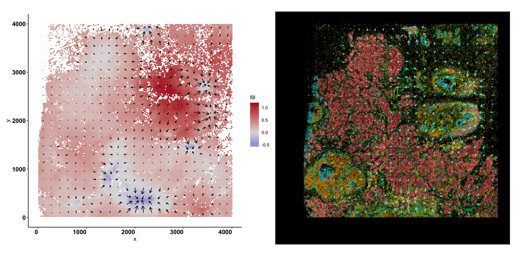

```r
p1|p2
```

## smFISH/MERFISH/MERRSCOPE dataset

```r
#** folder holding the tutorial datasets, adjust it to your local copy
data_dir <- "../../data"
HGSC2 <- readRDS(file.path(data_dir, "ST_Test2_HGSC2_so.rds"))
HGSC2@meta.data %>% head
```

```
#>               orig.ident nCount_RNA nFeature_RNA       samples patients
#> F001_c1005 SeuratProject        668          129 HGSC2_WT_F001    HGSC2
#> F001_c101  SeuratProject        364          101 HGSC2_WT_F001    HGSC2
#> F001_c1020 SeuratProject        342           99 HGSC2_WT_F001    HGSC2
#> F001_c1026 SeuratProject        828          127 HGSC2_WT_F001    HGSC2
#> F001_c1042 SeuratProject       1218          218 HGSC2_WT_F001    HGSC2
#> F001_c1046 SeuratProject       1038          206 HGSC2_WT_F001    HGSC2
#>            sites_binary cell.types cell.subtypes    x     y
#> F001_c1005       Adnexa     B.cell        B.cell 6458 44201
#> F001_c101        Adnexa   TNK.cell       NK.cell 6028 46486
#> F001_c1020       Adnexa   Monocyte      Monocyte 6885 44180
#> F001_c1026       Adnexa     B.cell     B.cell_LC 6336 44182
#> F001_c1042       Adnexa Fibroblast Fibroblast_LC 7827 44167
#> F001_c1046       Adnexa   Monocyte   Monocyte_LC 4336 44140
```

```r
HGSC2@meta.data[,c("x","y")] %>% summary()
```

```
#>        x               y
#>  Min.   :   17   Min.   :-4245
#>  1st Qu.:21120   1st Qu.:14640
#>  Median :29225   Median :26984
#>  Mean   :28742   Mean   :24707
#>  3rd Qu.:37354   3rd Qu.:35565
#>  Max.   :51061   Max.   :46806
```

As the coordinates range shown, this dataset covers a large spatial area. Thus we selected a ROI and filtered it. Due to the nature of smFISH and cell segmentation algorithms, overlapping cells may occur in this dataset. We remove those cells with distance less than 20 units (equivalent to 2 µm) Then, we normalize the expression of the remaining cells. Finally, spatial coordinates and cell annotation are extracted and converted to standardized units.

In the next code chunk, we will show detail code for this process. Each steps will be commented.

```r
#Select ROI and filter
ROI_barcode <-
HGSC2@meta.data %>%
  filter(x>23000,x<45000,y>-4300,y<10500) %>%
  rownames()

ROI <- subset(HGSC2, cells=ROI_barcode)

#ROI %>% VlnPlot(features = c("nFeature_RNA", "nCount_RNA"), ncol = 2, pt.size = 0)

ROI <- subset(ROI, subset = nCount_RNA < 3000)
ROI <- subset(ROI, subset = nFeature_RNA < 400)

#filter out overlap cells
df_ranged <- ROI@meta.data
coords <- cbind(df_ranged$x, df_ranged$y)
dmat <- as.matrix(dist(coords))
diag(dmat) <- NA
too_close <- which(apply(dmat, 1, min, na.rm=TRUE) < 20)
df_filtered <- df_ranged[-too_close, ]
ROI <- subset(ROI,cells=rownames(df_filtered))

#Normalize expr mat
ROI %<>% SCTransform()

#rescale coords to micrometer
ROI_coord  <-
  ROI@meta.data[,c("x","y")] %>%
  mutate(y=y-min(y)) %>%
  mutate(x=x/10,y=y/10)
ROI_coord$barcode <- rownames(ROI_coord)

#merge cell subtypes annotation
ROI@meta.data %<>%
  mutate(subtype=gsub("_LC","",cell.subtypes))
```

After pre-processing, we are ready to create spWAVE object and calculate the LR field. Here, we create by manually setting the parameters of coord and cluster.

```r
human_db <- load_database(db_source = "CellChat",db_species = "human")

ROI_spWAVE <- create_spWAVE_object(
  seurat_obj = ROI,
  database = human_db,
  coord = ROI_coord,
  cluster="subtype"
  )

ROI_spWAVE %<>% generate_kmeans_coord(centers=ncol(ROI)/20,iter.max=15,nstart=3)
ROI_spWAVE %<>% generate_meta_expr()

library(future)
future::plan("multicore",workers=16)
options(future.globals.maxSize = 100*1024^3)
ROI_spWAVE %<>% perform_LR_field_hole_calc()
ROI_spWAVE %<>% perform_S2S_score_calc()
ROI_spWAVE %<>% perform_C2C_score_calc(shuffle_iter=200,verbose=T)
```

Now, we can visualize the field result. Here we show the projection of “CXCL12-CXCR4” and “CXCL16-CXCR6” and compare them.

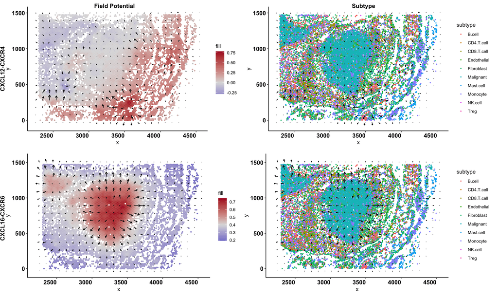

```r
library(patchwork)
library(cowplot)
#** folder holding the tutorial datasets, adjust it to your local copy
data_dir <- "../../data"
ROI <- readRDS(file.path(data_dir, "HGSC2_ROI_SO.rds"))
ROI_spWAVE <- readRDS(file.path(data_dir, "v2", "HGSC2_ROI_spWAVE_c2c_v2.rds"))


L12R4_field <- perform_field_extract(ROI_spWAVE,"CXCL12.CXCR4")
L12R4_field %<>% mutate(subtype=ROI@meta.data$subtype)

p1 <-
plot_field_direction2(L12R4_field,point="KU",
  hexified=T,hex_binwidth=c(20,20),
  arrow_color="black",
  arrow_linewidth = 0.5,
  #arrow_sf=0.001
  )+
  scale_fill_gradient2(low="#3B50C5", mid="#DCDCDC",high="#AD0C27")
p2 <-
plot_field_direction2(L12R4_field,
  arrow_color="black",
  arrow_linewidth = 0.5,
  point="subtype",point_size=0.5)

L16R6_field <- perform_field_extract(ROI_spWAVE,"CXCL16.CXCR6")
L16R6_field %<>% mutate(subtype=ROI@meta.data$subtype)

p3 <-
plot_field_direction2(L16R6_field,point="KU",
  hexified=T,hex_binwidth=c(20,20),
  arrow_color="black",
  arrow_linewidth = 0.5,
  #arrow_sf=0.001
  )+
  scale_fill_gradient2(low="#3B50C5", mid="#DCDCDC",high="#AD0C27",midpoint=0.4)
p4 <-
plot_field_direction2(L16R6_field,
  arrow_color="black",
  arrow_linewidth = 0.5,
  point="subtype",point_size=0.5)

p_all <- (p1|p2)/(p3|p4)

final_plot <- ggdraw(p_all) +
  draw_label("Field Potential", x = 0.23, y = 0.98, size = 12, fontface = "bold") +
  draw_label("Subtype", x = 0.73, y = 0.98, size = 12, fontface = "bold") +
  draw_label("CXCL12-CXCR4", x = 0.005, y = 0.77, angle = 90, size = 12, fontface = "bold") +
  draw_label("CXCL16-CXCR6", x = 0.005, y = 0.27, angle = 90, size = 12, fontface = "bold")
final_plot
```

Since we directly utilized the ‘point’ parameter in the ‘plot_field_direction2’ function to visualize cell types, the resulting background differs from the first example, presenting a white background instead. In contrast, the black background is generated by the plotting function from the Seurat package.

Notably, the point parameter can also accept discrete variables such as character vectors and factors. And the value should be a column in the field result data.frame, like the ‘subtype’ in our example. In such cases, different colors can be assigned by providing a named vector to the ‘point_color’ parameter.